# Chi-squared test

Inferential statistics

Author

Affiliation

Vladimir Buskin

Catholic University of Eichstätt-Ingolstadt

Abstract

The chi-squared ($\chi^2$) test helps determine if there is a statistically significant association between two categorical variables. It compares the observed frequencies of categories with those expected under the null hypothesis. The $\chi^2$ (chi-squared) score quantifies the difference between observed and expected frequencies for every cell in a contingency table. The greater the difference between observed and expected, the higher the $\chi^2$ score and the lower the $p$-value, given the degrees of freedom. It is recommended to compute effect size measures and inspect the residuals to assess the nature of the association.

## 1 Suggested reading

For linguists:

> Gries (2021): Chapter 4.1.2.1

General:

> Baguley (2012): Chapter 4

> Agresti and Kateri (2022): Chapter 5

## 2 Preparation

**Script**

You can find the full R script associated with this unit [here](https://osf.io/u7f8w).

```r
#  Load libraries
library(readxl)
library(tidyverse)
library(confintr) # for effect size calculation

# Load data
cl.order <- read_xlsx("../datasets/Paquot_Larsson_2020_data.xlsx")
```

## 3 The Pearson $\chi^2$-test of independence

The first step of any significance test involves setting up the null and alternative hypothesis. In this unit, we will perform a sample analysis on the relationship between clause `ORDER` and the type of subordinate clause (`SUBORDTYPE`). Specifically, we will focus on the **independence** of these two discrete variables (i.e, the presence or absence of correlation).

- $H_0:$ The variables `ORDER` and `SUBORDTYPE` are independent.
- $H_1:$ The variables `ORDER` and `SUBORDTYPE` are **not** independent.

**What does independence really mean?**

The core idea is “that the probability distribution of the response variable is the same for each group” (Agresti and Kateri 2022: 177). If clause `ORDER` is the response variable and `SUBORDTYPE` the explanatory variable, independence would entail that the probabilities of the outcomes of the response variable `ORDER = "mc-sc"` and `ORDER = "sc-mc"` are not influenced by whether they occur in the groups `SUBORDTYPE = "temp"` or `SUBORDTYPE = "caus"`.

The term **probability distribution** refers to a mathematical function that assigns probabilities to the outcomes of a variable. If we consider two variables at the same time, such as $X$ and $Y$, they are said to have **marginal probability functions** $f_1(x)$ and $f_2(y)$. If we condition the outcomes of all values on each other, the following equivalence will hold:

$$f(x \mid y) = f_1(x) \text{ and } f(y \mid x) = f_2(y).
\tag{1}$$

Thus, the null hypothesis assumes that the probabilities of each combination of values (such as `ORDER` and `SUBORDTYPE`), denoted by $\pi_{ij}$, have the relationship in Equation 1. This can be stated succinctly as

$$H_0 : \pi_{ij} = P(X = j)P(Y = i).
\tag{2}$$

Next, we compute a test statistic that indicates how strongly our data conforms to $H_0$, such as Pearson’s $\chi^2$. To this end, we will need two types of values:

- the **observed frequencies** $f_{ij}$ present in our data set
- the **expected frequencies** $e_{ij}$, which we would expect to see if $H_0$ were true,

where $f, e \in \mathbb{N}$. The indices $i$ and $j$ uniquely identify the cell counts in all column-row combinations of a contingency table.

### 3.1 Observerd frequencies

The table below represents a generic contingency table where $Y$ and $X$ are categorical variables and have the values $Y = \{y_1, y_2, \dots, y_i \}$ and $X = \{x_1, x_2, \dots, x_j\}$. In the table, each cell indicates the count of observation $f_{ij}$ corresponding to the $i$-th row and $j$-th column.

|  |  |  | $X$ |  |  |  |
| --- | --- | --- | --- | --- | --- | --- |
|  |  | $x_1$ | $x_2$ | … | $x_j$ |  |
|  | $y_1$ | $f_{11}$ | $f_{12}$ | … | $f_{1j}$ |  |
|  | $y_2$ | $f_{21}$ | $f_{22}$ | … | $f_{2j}$ |  |
| $Y$ | … | … | … | … | … |  |
|  | $y_i$ | $f_{i1}$ | $f_{i2}$ | … | $f_{ij}$ |  |

In the `cl.order` data, the **observed frequencies** correspond to how often each `ORDER` value (i.e., `mc-sc` and `sc-mc`) is attested for a given `SUBORDTYPE` (i.e., `temp` and `caus`). This can be done in a very straightforward fashion using R’s `table()` function on the variables of interest.

```r
observed_freqs <- table(cl.order$ORDER, cl.order$SUBORDTYPE)

print(observed_freqs)
```

```
        caus temp
  mc-sc  184   91
  sc-mc   15  113
```

### 3.2 Expected frequencies

The **expected frequencies** require a few additional steps. Usually, these steps are performed automatically when conducting the chi-squared test in R, so you don’t have to worry about calculating them by hand. We will do it anyway to drive home the rationale of the test.

|  |  |  | $X$ |  |  |  |
| --- | --- | --- | --- | --- | --- | --- |
|  |  | $x_1$ | $x_2$ | … | $x_j$ |  |
|  | $y_1$ | $e_{11}$ | $e_{12}$ | … | $e_{1j}$ |  |
|  | $y_2$ | $e_{21}$ | $e_{22}$ | … | $e_{2j}$ |  |
| $Y$ | … | … | … | … | … |  |
|  | $y_i$ | $e_{i1}$ | $e_{i2}$ | … | $e_{ij}$ |  |

The expected frequencies $e_{ij}$ are given by the formula in Equation 3. In concrete terms, we go through each cell in the cross-table and multiply the corresponding row sums with the column sums, dividing the result by the total number of occurrences in the sample. For example, there are $184$ occurrences of `mc-sc` clause orders where the subordinate clause is causal. The row sum is $184 + 91 = 275$ and the column sum is $184 + 15 = 199$. Next, we take their product $275 \times 199$ and divide it by the total number of observations, which is $184 + 91 + 15 + 113 = 403$. Thus we obtain an expected frequency of $\frac{275 \times 199}{403} = 135.79$ under the null hypothesis.

$$e_{ij} = \frac{i\textrm{th row sum} \times j \textrm{th column sum}}{\textrm{number of observations}}
\tag{3}$$

The expected frequencies for our combination of variables is shown below. In which cells can you see the greatest deviations between observed and expected frequencies?

```r
## Calculate row totals
row_totals <- rowSums(observed_freqs)

## Calculate column totals
col_totals <- colSums(observed_freqs)

## Total number of observations
total_obs <- sum(observed_freqs)

## Calculate expected frequencies
expected_freqs <- outer(row_totals, col_totals) / total_obs

print(expected_freqs)
```

```
           caus      temp
mc-sc 135.79404 139.20596
sc-mc  63.20596  64.79404
```

### 3.3 Conducting the test

The $\chi^2$-test now offers a convenient way of quantifying the differences between the two tables above. It measures how much the observed frequencies **deviate** from the expected frequencies **for each cell** in a contingency table (cf. Heumann, Schomaker, and Shalabh 2022: 249-251). The gist of this procedure is summarised in Equation 4.

$$\text{Chi-squared } \chi^2 =\frac{(\text{observed} - \text{expected})^2}{\text{expected}}
\tag{4}$$

**Formal definition of the $\chi^2$-test**

Given $n$ observations and $k$ degrees of freedom $df$, the joint squared deviations between $f_{ij}$ and $e_{ij}$ contribute to the final $\chi^2$-score, which is defined as

$$\chi^2 = \sum_{i=1}^{I}\sum_{j=1}^{J}{\frac{(f_{ij} - e_{ij})^2}{e_{ij}}}
\tag{5}$$

for $i = 1, ..., I$ and $j = 1, ..., J$ and $df = (\textrm{number of rows} -1) \times (\textrm{number of columns} - 1)$.

Applying the formula, the updated contingency would have the following form:

|  |  |  | $X$ |  |  |  |
| --- | --- | --- | --- | --- | --- | --- |
|  |  | $x_1$ | $x_2$ | … | $x_j$ |  |
|  | $y_1$ | $\frac{(f_{11} - e_{11})^2}{e_{11}}$ | $\frac{(f_{12} - e_{12})^2}{e_{12}}$ | … | $\frac{(f_{1j} - e_{1j})^2}{e_{1j}}$ |  |
|  | $y_2$ | $\frac{(f_{21} - e_{21})^2}{e_{21}}$ | $\frac{(f_{22} - e_{22})^2}{e_{22}}$ | … | $\frac{(f_{2j} - e_{2j})^2}{e_{2j}}$ |  |
| $Y$ | … | … | … | … | … |  |
|  | $y_i$ | $\frac{(f_{i1} - e_{i1})^2}{e_{i1}}$ | $\frac{(f_{i2} - e_{i1})^2}{e_{i2}}$ | … | $\frac{(f_{ij} - e_{ij})^2}{e_{ij}}$ |  |

The implementation in R is a simple one-liner. Keep in mind that we have to supply **absolute frequencies** to `chisq.test()` rather than percentages.

```r
freqs_test <- chisq.test(observed_freqs)

print(freqs_test)
```

```
    Pearson's Chi-squared test with Yates' continuity correction

data:  observed_freqs
X-squared = 104.24, df = 1, p-value < 2.2e-16
```

Quite conveniently, the test object `freqs_test` stores the expected frequencies, which can be easily accessed via subsetting. Luckily, they are identical to what we calculated above!

```r
freqs_test$expected
```

```
             caus      temp
  mc-sc 135.79404 139.20596
  sc-mc  63.20596  64.79404
```

### 3.4 Assumptions of the chi-squared test

This $\chi^2$-test comes with certain **statistical assumptions**. Violations of these assumptions decrease the validity of the result and could, therefore, lead to wrong conclusions about relationships in the data. In this case, other tests should be consulted.

**Important**

1. All observations are independent of each other.
2. 80% of the expected frequencies are $\geq$ 5.
3. All observed frequencies are $\geq$ 1.

If assumptions 2 and 3 are violated, it is recommended to use a more robust test such as the **Fisher’s Exact Test** or the **log-likelihood ratio test** ($G$-test).

**Fisher’s Exact Test**

While the $\chi^2$-test can only approximate the $p$-value, Fisher’s Exact Test can provide an exact solution. Note that for anything more complex than a $2 \times 2$ table, it becomes considerably more computationally expensive; if it takes too long, set `simulate.p.value = TRUE`.

Drawing on the hypergeometric distribution (see `?dhyper()`), it computes the probability of all frequency tables that are equal or more extreme than the one observed.

```r
fisher.test(observed_freqs)
```

```
    Fisher's Exact Test for Count Data

data:  observed_freqs
p-value < 2.2e-16
alternative hypothesis: true odds ratio is not equal to 1
95 percent confidence interval:
  8.216959 29.548120
sample estimates:
odds ratio
  15.11768
```

**$G$-test**

The $G^2$-statistic is analogous to $\chi^2$, but it tends to be more robust for lower observed counts. It is defined as

$$G^2 = 2\sum_{i=1}^{I}\sum_{j=1}^{J} f_{ij} \ln\left({\frac{f_{ij}}{e_{ij}}}\right)
\tag{6}$$

and implemented in R via the `DescTools` package.

```r
# Load library (install if necessary)
library(DescTools)

# Perform G-test (preferably for tables with more than 2 rows/columns)
GTest(observed_freqs)
```

```
    Log likelihood ratio (G-test) test of independence without correction

data:  observed_freqs
G = 116.97, X-squared df = 1, p-value < 2.2e-16
```

### 3.5 How do I make sense of the test results?

The test output has three ‘ingredients’:

- the **chi-squared score** (X-squared)
- the **degrees of freedom** (df)
- the **p-value**.

It is absolutely essential to report all three of those as they determine each other. Here a few possible wordings that could be used:

The test results suggest that the dependent variable `ORDER` and the explanatory variable `SUBORDTYPE` are not independent of each other. The probability of **randomly** observing usage patterns such as those found in the `cl.order` data is lower than 0.001 $\approx$ 0.1%, which is enough to reject the null hypothesis at $\alpha = 0.05$.

We can infer that a speaker’s choice of clause `ORDER` is very likely influenced by the semantic type of subordinate clause; in other words, these two variables are **correlated**. However, there are still several things the test does **not** tell us:

- Are there certain variable combinations where the $\chi^2$-scores are particularly high?
- How strongly do `ORDER` and `SUBORDTYPE` influence each other?

## 4 Pearson residuals

If we’re interested in what cells show the greatest difference between observed and expected frequencies, an option would be to inspect the Pearson residuals (cf. Equation 7).

$$\text{residuals} = \frac{\text{observed} - \text{expected}}{\sqrt{\text{expected}}}
\tag{7}$$

These can be accessed via the test results stored `freqs_test`.

```r
freqs_test$residuals
```

```
             caus      temp
  mc-sc  4.136760 -4.085750
  sc-mc -6.063476  5.988708
```

The function `assocplot()` can automatically compute the pearson residuals for any given contingency table and create a plot that highlights their contributions. If the bar is above the dashed line, it is black and indicates that a category is observed more frequently than expected (e.g., causal subordinate clauses in the `mc-sc` order). Conversely, bars are coloured grey if a category is considerably less frequent than expected, such as `caus` in `sc-mc`.

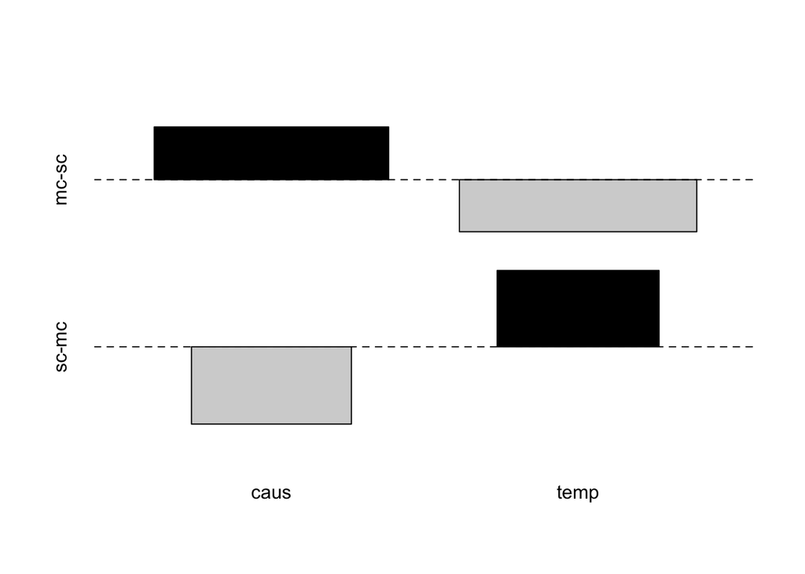

```r
assocplot(t(observed_freqs), col = c("black", "lightgrey"))
```

**Testing the residuals: Configural Frequency Analysis**

The chi-squared test only provides a $p$-value for the entire contingency table. But what if we wanted to test the residuals for their significance as well? Configural Frequency Analysis (Krauth and Lienert 1973) allows us to do exactly that: It performs a significance test for **all combinations of variable values** in a cross-table. Moreover, CFA is not limited to two variables only. Technically, users can test for associations between arbitrary numbers of variables, but should be aware of the increasing complexity of interpretation.

```r
library(cfa) # install library beforehand

# Get the observed counts and convert them to a data frame
config_df <- as.data.frame(observed_freqs)

# Convert to matrix
configs <- as.matrix(config_df[, 1:2])  # first two columns contain the configurations (= combinations of variable values)
counts <- config_df$Freq # Freq column contains the corresponding counts

# Perform CFA on configuarations and counts; apply Bonferroni correction for multiple testing
cfa_output <- cfa(configs, counts, bonferroni = TRUE)

# Print output
print(cfa_output)
```

```
*** Analysis of configuration frequencies (CFA) ***

       label   n  expected         Q    chisq      p.chisq sig.chisq         z
1 sc-mc caus  15  63.20596 0.1418682 36.76575 1.332103e-09      TRUE -6.671872
2 sc-mc temp 113  64.79404 0.1425343 35.86463 2.115143e-09      TRUE  6.469444
3 mc-sc caus 184 135.79404 0.1804075 17.11278 3.522441e-05      TRUE  5.027611
4 mc-sc temp  91 139.20596 0.1827409 16.69335 4.393467e-05      TRUE -5.102385
           p.z sig.z
1 1.000000e+00  TRUE
2 4.918210e-11  TRUE
3 2.483137e-07  TRUE
4 9.999998e-01  TRUE


Summary statistics:

Total Chi squared         =  106.4365
Total degrees of freedom  =  1
p                         =  0
Sum of counts             =  403

Levels:

Var1 Var2
   2    2
```

## 5 Effect size

The $p$-value only indicates the **presence of correlation**, but not its strength – regardless of how low it may be. It does not convey how much two variables determine each other. For this reason, it is highly recommended to report an **effect size measure** alongside the $p$-value. One such measure is Cramér’s $V$, which takes values in the interval $[0, 1]$:

$$V = \sqrt{\frac{\chi^2}{n \times (min(nrow, ncol) - 1)}}.
\tag{8}$$

The package `confintr` implements this in its `cramersv()` function:

```r
cramersv(freqs_test)
```

```
[1] 0.5085863
```

The association between two categorical variables is stronger, the closer $V$ approximates 1. Conversely, if $V = 0$, then the variables are completely independent. There are various guidelines in the literature that provide thresholds for “small”, “moderate” and “large” effects, yet these are rarely justified on theoretical grounds and could be viewed as arbitrary.

## 6 Only one variable? The Pearson $\chi^2$ goodness-of-fit test

The $\chi^2$-statistic can also be utilised in simpler scenarios that involve only one single categorical variable.[^1] Consider the small [`eat_obj_aspect.xlsx`](https://osf.io/y5scq) dataset, where the `object_realisation` column indicates whether the object was realised or dropped in a given observation.

```r
# Load data
eat <- read_xlsx("../datasets/eat_obj_aspect.xlsx")

# Show object realisation pattern
eat_observed <- table(eat$object_realisation)

print(eat_observed)
```

```
 no yes
 57  45
```

We can use the $\chi^2$ **goddness-of-fit test** “to compare an observed frequency distribution against its expected probability of occurrence” (Baguley 2012: 132). In other words, we can check if the observed object data matches the frequencies we’d expect to see if both outcomes of `object realisation` were equally likely and hence randomly distributed.

Our hypotheses are thus

- $H_0:$ Observed frequencies of `object realisation` $=$ expected frequencies of `object realisation`
- $H_1:$ Observed frequencies of `object realisation` $\neq$ expected frequencies of `object realisation`

The expected frequencies are given by

$$e_i = \frac{\text{number of observations}}{\text{number of cells}},
\tag{9}$$

and the test statistic simplifies to

$$\chi^2 = \sum_{i=1}^{I}{\frac{(f_{i} - e_{i})^2}{e_{i}}}.
\tag{10}$$

**In R**:

```r
# Perform the chi-squared goodness-of-fit test
eat_gof <-  chisq.test(eat_observed)

print(eat_gof)
```

```
    Chi-squared test for given probabilities

data:  eat_observed
X-squared = 1.4118, df = 1, p-value = 0.2348
```

```r
# Check expected frequencies (should be greater or equal to 5)
print(eat_gof$expected)
```

```
 no yes
 51  51
```

> A chi-squared goodness-of-fit test indicates that the distribution of object realisation for *eat* does not significantly differ from an equal distribution ($\chi^2$ = 1.41, $df$ = 1, $p$ = 0.23). In the sample at hand, the verb *eat* does not seem to prefer one variant or the other.

## 7 Exercises

**Solutions**

You can find the solutions to the exercises [here](https://osf.io/m8et2).

**Exercise 1** Load the file [`eat_obj_aspect.xlsx`](https://osf.io/y5scq) into R. It contains hits for the verb lemma *eat* which were annotated for the presence or absence of a direct object (`object_realisation` column) and for the aspect of the verb (`verb_aspect` column).

- Create a frequency table that cross-classifies `object_realisation` and `verb_aspect`.
- Forward a set of statistical hypotheses.
- Perform a $\chi^2$-test of independence and interpret the result.

**Exercise 2** The `chisq.test()` returns a warning message: “Chi-squared approximation may be incorrect”. Examine the frequency table for potential violations of the test assumptions. How could you control for them?

## References

Agresti, Alan, and Maria Kateri. 2022. *Foundations of Statistics for Data Scientists: With r and Python*. Boca Raton: CRC Press.

Baguley, Thomas. 2012. *Serious Stats: A Guide to Advanced Statistics for the Behavioral Sciences*. Houndmills, Basingstoke: Palgrave Macmillan.

Gries, Stefan Thomas. 2021. *Statistics for Linguistics with r: A Practical Introduction*. 3rd rev. ed. Berlin; Boston: De Gruyter Mouton.

Heumann, Christian, Michael Schomaker, and Shalabh. 2022. *Introduction to Statistics and Data Analysis: With Exercises, Solutions and Applications in r*. 2nd ed. Cham: Springer. https://doi.org/10.1007/978-3-031-11833-3.

Krauth, J., and G. A. Lienert. 1973. *Die Konfigurationsfrequenzanalyse (KFA) Und Ihre Anwendung in Psychologie Und Medizin*. Reprint 1995. Weinheim: Beltz Psychologie Verlagsunion.

## Footnotes

[^1]: For this reason, the distinction between dependent and independent variable is irrelevant here.